# TarefaDois

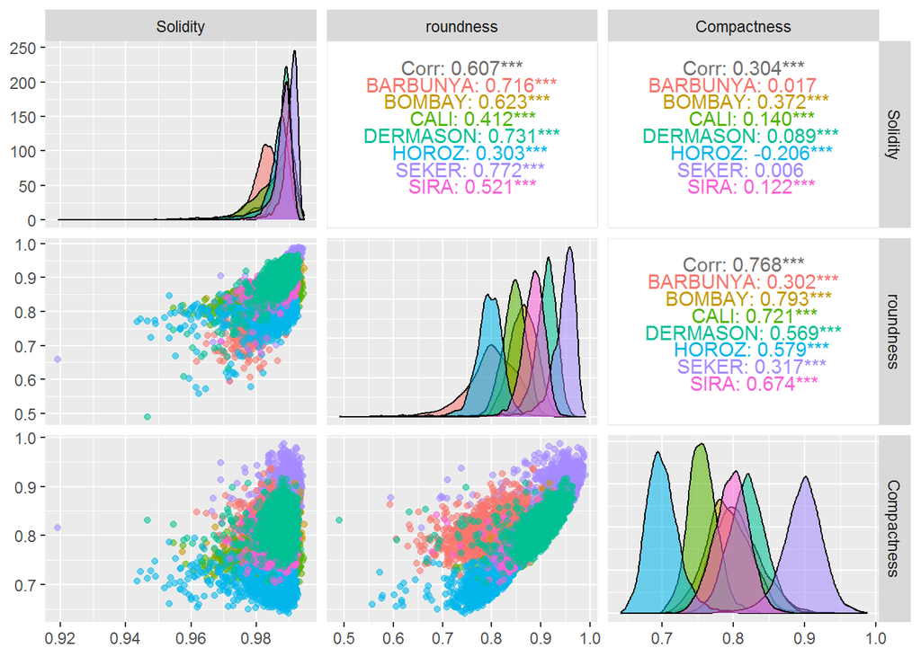

```r
ggpairs(dados[,10:12],aes(colour=dados$Class,alpha=0.4))
```

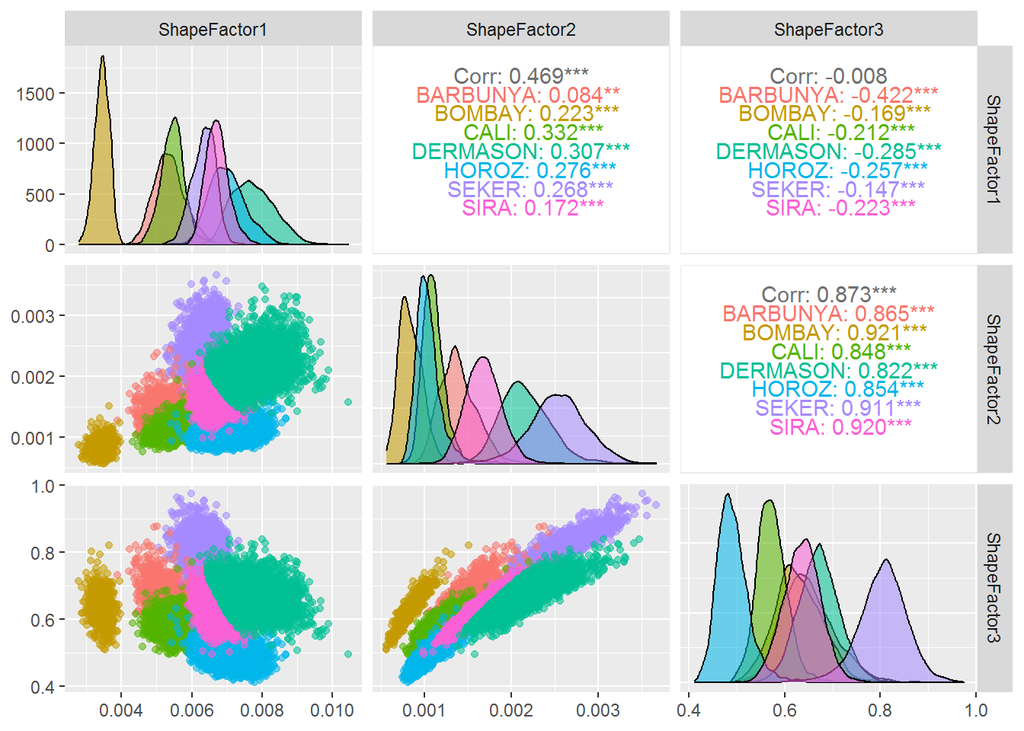

```r
ggpairs(dados[,13:15],aes(colour=dados$Class,alpha=0.4))
```

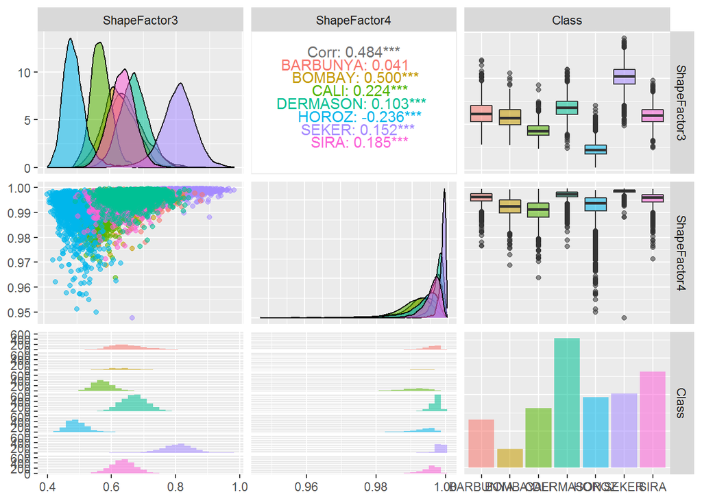

```r
ggpairs(dados[,15:17],aes(colour=dados$Class,alpha=0.4))
```

### 9.É possível reduzir a dimensionalidade dos dados? Explique como!

### Sim é possível reduzir a dimensionalidade dos dados. A redução pode ser obtida por meio da remoção de informações irrelevantes/redundantes ou uma representação compacta e informativa dos dados originais. O mapeamento das entradas em um espaço original de d dimensões é realizado para um novo espaço com dimensões k (onde k <d), com uma perda mínima de informações.

### 10.Analise o dataset reduzido com o auxílio do gráfico de boxplot por classe (igual ao do item 6). Compare com o resultado do item 6 e do item 8. Se quiser, pode gerar um gráfico de espalhamento para auxiliar na explicação.

```r
nComp = 3
dadosReduzidos = predict(pca, dados)[,1:nComp]
summary(dadosReduzidos)
```

```
##       PC1               PC2               PC3
##  Min.   :-2.8129   Min.   :-3.4351   Min.   :-0.31683
##  1st Qu.:-1.2870   1st Qu.:-0.5699   1st Qu.:-0.03773
##  Median :-0.4688   Median :-0.0226   Median :-0.01526
##  Mean   : 0.0000   Mean   : 0.0000   Mean   : 0.00000
##  3rd Qu.: 1.0646   3rd Qu.: 0.4367   3rd Qu.: 0.01140
##  Max.   : 8.7164   Max.   : 3.4504   Max.   : 0.90290
```

```r
cores = c("red","green","blue","yellow","darkred","black","brown")
par(mfrow=c(1,3))
for (i in 1:16) {
boxplot(dados[,i] ~ dados$Class, col=cores, xlab="Tipo de feijão",
ylab="", main=names(dados)[i])
}
```

[output not shown]

### Pode-se observar que quanto maior o poder de discriminação, possuí também uma alta taxa de correlação. Pode-se perceber que a classe BOMBAY destaca-se das demais.

### 11. Após ter analisado estas informações, quais considerações você faz sobre este conjunto de dados (ou tarefa)?

### Esse conjunto de dados (dataset) DryBeans em complemento a tarefa 1 foi possível observar a relação com os gráficos de espalhamento (correlação) e boxplot (com o poder de discriminação). Foi possível visualizar as informações obtidas, padrões e comportamento das informações através dos gráficos.